# Homework #5

Dustin Leatherman

October 18, 2020

> Refer to the dataset ConcussionsByTeamAndYear.csv found under the Week Six course content of D2L. Let $Y_i$ be the number of concussions from team $i = 1, ..., 32$. The model is $Y_i | \lambda_i \sim Poisson(\lambda_i)$ and the prior is $\lambda_i | \theta \sim Gamma(1, \theta)$ where $\theta \sim Gamma(0.1, 0.1)$.

# 1

> Derive the full conditional distribution of $\lambda_1$.

$$\begin{equation}
\begin{split}
\label{eq:1}
f(\lambda_1 | Y, \theta) \propto & f(Y, | \lambda_1, \theta) f(\lambda_1 | \theta)\\
= & f(Y | \lambda_1, \theta) f(\theta) f(\lambda_1 | \theta)\\
= & \frac{e^{-\lambda_1} \lambda_1^{Y}}{Y !} \cdot \theta^{0.1 - 1} e^{- 0.1 \theta} \cdot \theta e^{- \theta \lambda_1}\\
\propto & \theta^{0.1} \lambda^Y e^{-\lambda_1 - 0.1 \theta - \theta \lambda_1}
\end{split}
\end{equation}$$

When holding everything but $\lambda_1$, then

$$f(\lambda_1 | Y, \theta) \propto \lambda^{Y + 1} e^{- \lambda_1 (\theta + 1)} \sim Gamma(Y + 1, \theta + 1)$$

# 2

> Derive the full conditional distribution of $\theta$.

Following the result in (a) and holding $\theta$ fixed,

$$\begin{equation}
\begin{split}
f(\theta | Y, \lambda_1, ..., \lambda_p) \propto & \prod_{i = 1}^{p} \theta^{0.1} e^{-\theta(0.1 + \lambda_i)}\\
= & \theta^{\frac{p}{10}} exp(-\theta[\frac{p}{10} + \sum_{i = i}^{p} \lambda_i])\\
= & \theta^{\frac{p}{10} + 1 - 1} exp(-\theta[\frac{p}{10} + \sum_{i = i}^{p} \lambda_i])\\
\sim & Gamma(\frac{p}{10} + 1, \sum_{i = 1}^{p} \lambda_i + \frac{p}{10})
\end{split}
\end{equation}$$

Where p = 32.

# 3

> Write Gibbs sampling code to draw samples from the joint distribution of $(\lambda_1, ..., \lambda_{32}, \theta)$.

```r
num.teams <- 32
num.params <- num.teams + 1 # for theta
n.iters <- 30000

res.2012 <- res.2013 <- matrix(0,n.iters, num.params)
lambda.names <- sapply(1:num.teams, function(x) paste0("lambda_", x))
colnames(res.2012) <- colnames(res.2013) <- c(lambda.names,"theta")

# initial values for first row
lambdas.init <- concussions %>%
  mutate(mean = (X2012 + X2013) / 2)

theta <- 0.1
lambdas <- lambdas.init
res.2012[1,] <- res.2013[1,] <- c(lambdas.init$mean, theta)

# The loop to perform Gibbs sampling
for(i in 2:n.iters){
  # Random draw from full conditional distribution of lambdas
  lambdas.2012 <- rgamma(num.teams, lambdas.init$X2012 + 1, theta + 1)
  lambdas.2013 <- rgamma(num.teams, lambdas.init$X2013 + 1, theta + 1)

  # Random draw from full conditional distribution of theta
  theta.2012 <- rgamma(1, (num.teams/10) + 1, sum(lambdas.2012) + (num.teams/10))
  theta.2013 <- rgamma(1, (num.teams/10) + 1, sum(lambdas.2013) + (num.teams/10))

  res.2012[i,] <- c(lambdas.2012, theta.2012)
  res.2013[i,] <- c(lambdas.2013, theta.2013)
}
res.2012 <- as.data.frame(res.2012)
res.2013 <- as.data.frame(res.2013)
```

# 4

> Show trace plots of the samples for $\lambda_1$ and $\theta$. (These plots of the value of the parameter on the y-axis and the iteration number on the x-axis).

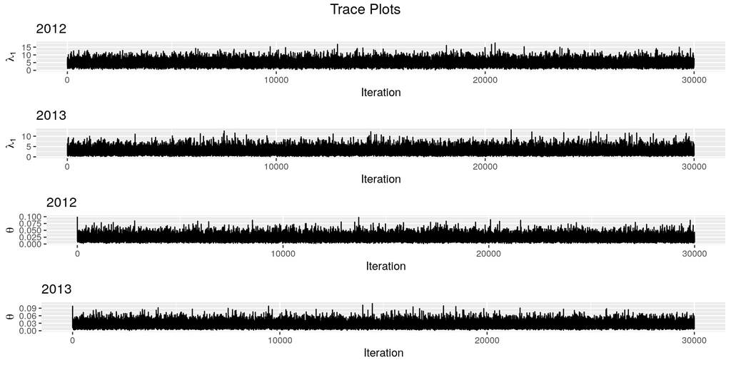

```r
p1 <-
  res.2012 %>%
    ggplot(aes(x = 1:n.iters, y = lambda_1)) +
    geom_line() +
    labs(x = "Iteration", y = expression(lambda[1])) +
    ggtitle("2012")

p2 <-
  res.2013 %>%
    ggplot(aes(x = 1:n.iters, y = lambda_1)) +
    geom_line() +
    labs(x = "Iteration", y = expression(lambda[1]))+
    ggtitle("2013")

p3 <-
  res.2012 %>%
    ggplot(aes(x = 1:n.iters, y = theta)) +
    geom_line() +
    labs(x = "Iteration", y = expression(theta))+
    ggtitle("2012")

p4 <-
  res.2013 %>%
    ggplot(aes(x = 1:n.iters, y = theta)) +
    geom_line() +
    labs(x = "Iteration", y = expression(theta))+
    ggtitle("2013")
grid.arrange(
  p1,
  p2,
  p3,
  p4,
  ncol = 1,
  top = textGrob("Trace Plots",
                            gp=gpar(fontsize=14,font=1),just=c("center"))
)
```

# 5

> Plot the estimated posterior mean of $\lambda_i$ versus $Y_i$ and comment on whether the code is returning reasonable estimates

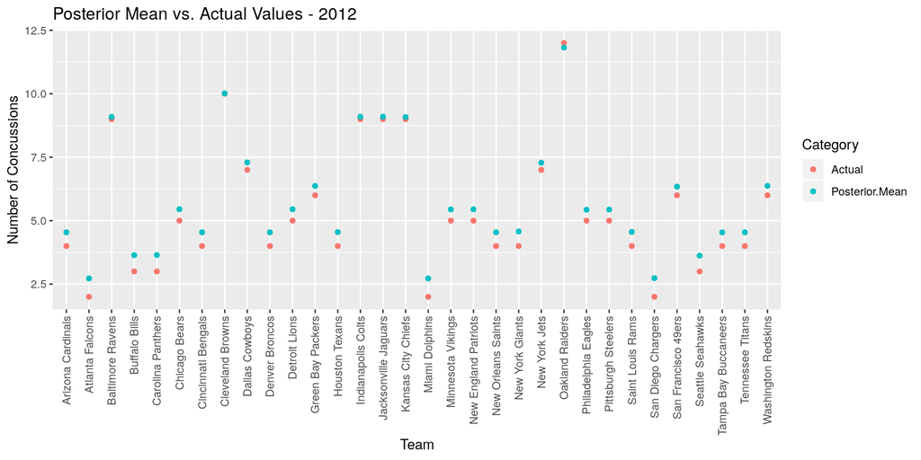

```r
lambdas.mean.2012 <- colMeans(res.2012) %>% head(-1)
concussions %>%
  bind_cols(Posterior.Mean = lambdas.mean.2012) %>%
  select(X, Actual = X2012, Posterior.Mean) %>%
  pivot_longer(-X, names_to = "Category", values_to = "value") %>%
  mutate(X = str_remove(X, "\xa0")) %>%
  ggplot(aes(x = X, color = Category, y = value)) +
  geom_point() +
  theme(axis.text.x = element_text(angle = 90, vjust = 0.5, hjust=1)) +
  labs(x = "Team", y = "Number of Concussions") +
  ggtitle("Posterior Mean vs. Actual Values - 2012")
```

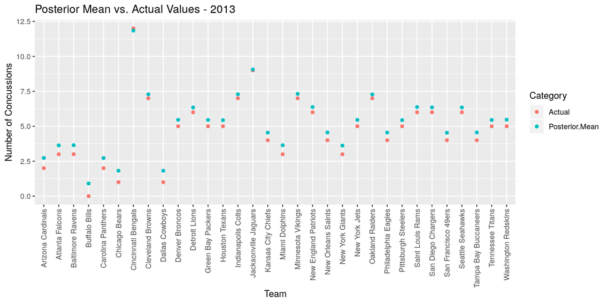

```r
lambdas.mean.2013 <- colMeans(res.2013) %>% head(-1)
concussions %>%
  bind_cols(Posterior.Mean = lambdas.mean.2013) %>%
  select(X, Actual = X2013, Posterior.Mean) %>%
  pivot_longer(-X, names_to = "Category", values_to = "value") %>%
  mutate(X = str_remove(X, "\xa0")) %>%
  ggplot(aes(x = X, color = Category, y = value)) +
  geom_point() +
  theme(axis.text.x = element_text(angle = 90, vjust = 0.5, hjust=1)) +
  labs(x = "Team", y = "Number of Concussions") +
  ggtitle("Posterior Mean vs. Actual Values - 2013")
```

The posterior mean is pretty close to the actual estimates for each year indicating that this is not a bad model.